# Project: TMDb - Movies Data Analysis

- Introduction
- Data Wrangling
- Exploratory Data Analysis
- Conclusions

## Introduction

This data set contains information about 10,000 movies from 1960 to 2015 collected from The Movie Database (TMDb), including various columns about the details of the movies, user ratings and revenue.

- Certain columns, like ‘cast’ and ‘genres’, contain multiple values separated by pipe (|) characters.
- There are some odd characters in the ‘cast’ column. Don’t worry about cleaning them. You can leave them as is.
- The final two columns ending with “_adj” show the budget and revenue of the associated movie in terms of 2010 dollars, accounting for inflation over time

The dataset characteristics has been investigated according to 2 major factors:

### Setup

```python
# import pakcages and libraries needed for the projec
import numpy as np
import pandas as pd
import matplotlib.pyplot as plt
import seaborn as sns
%matplotlib inline
sns.set_style('darkgrid')
```

## Data Wrangling

### Assessing & Building Intuition

```python
# Loading data and printing out a few lines.
df = pd.read_csv("tmdb-movies.csv")
df.head()
```

|  | id | imdb_id | popularity | budget | revenue | original_title | cast | homepage | director | tagline | ... | overview | runtime | genres | production_companies | release_date | vote_count | vote_average | release_year | budget_adj | revenue_adj |
| --- | --- | --- | --- | --- | --- | --- | --- | --- | --- | --- | --- | --- | --- | --- | --- | --- | --- | --- | --- | --- | --- |
| 0 | 135397 | tt0369610 | 32.985763 | 150000000 | 1513528810 | Jurassic World | Chris Pratt\|Bryce Dallas Howard\|Irrfan Khan\|Vi... | http://www.jurassicworld.com/ | Colin Trevorrow | The park is open. | ... | Twenty-two years after the events of Jurassic ... | 124 | Action\|Adventure\|Science Fiction\|Thriller | Universal Studios\|Amblin Entertainment\|Legenda... | 6/9/15 | 5562 | 6.5 | 2015 | 1.379999e+08 | 1.392446e+09 |
| 1 | 76341 | tt1392190 | 28.419936 | 150000000 | 378436354 | Mad Max: Fury Road | Tom Hardy\|Charlize Theron\|Hugh Keays-Byrne\|Nic... | http://www.madmaxmovie.com/ | George Miller | What a Lovely Day. | ... | An apocalyptic story set in the furthest reach... | 120 | Action\|Adventure\|Science Fiction\|Thriller | Village Roadshow Pictures\|Kennedy Miller Produ... | 5/13/15 | 6185 | 7.1 | 2015 | 1.379999e+08 | 3.481613e+08 |
| 2 | 262500 | tt2908446 | 13.112507 | 110000000 | 295238201 | Insurgent | Shailene Woodley\|Theo James\|Kate Winslet\|Ansel... | http://www.thedivergentseries.movie/#insurgent | Robert Schwentke | One Choice Can Destroy You | ... | Beatrice Prior must confront her inner demons ... | 119 | Adventure\|Science Fiction\|Thriller | Summit Entertainment\|Mandeville Films\|Red Wago... | 3/18/15 | 2480 | 6.3 | 2015 | 1.012000e+08 | 2.716190e+08 |
| 3 | 140607 | tt2488496 | 11.173104 | 200000000 | 2068178225 | Star Wars: The Force Awakens | Harrison Ford\|Mark Hamill\|Carrie Fisher\|Adam D... | http://www.starwars.com/films/star-wars-episod... | J.J. Abrams | Every generation has a story. | ... | Thirty years after defeating the Galactic Empi... | 136 | Action\|Adventure\|Science Fiction\|Fantasy | Lucasfilm\|Truenorth Productions\|Bad Robot | 12/15/15 | 5292 | 7.5 | 2015 | 1.839999e+08 | 1.902723e+09 |
| 4 | 168259 | tt2820852 | 9.335014 | 190000000 | 1506249360 | Furious 7 | Vin Diesel\|Paul Walker\|Jason Statham\|Michelle ... | http://www.furious7.com/ | James Wan | Vengeance Hits Home | ... | Deckard Shaw seeks revenge against Dominic Tor... | 137 | Action\|Crime\|Thriller | Universal Pictures\|Original Film\|Media Rights ... | 4/1/15 | 2947 | 7.3 | 2015 | 1.747999e+08 | 1.385749e+09 |

5 rows × 21 columns

```python
# printing names of the columns in the dataset
df.columns
```

```
Index(['id', 'imdb_id', 'popularity', 'budget', 'revenue', 'original_title',
       'cast', 'homepage', 'director', 'tagline', 'keywords', 'overview',
       'runtime', 'genres', 'production_companies', 'release_date',
       'vote_count', 'vote_average', 'release_year', 'budget_adj',
       'revenue_adj'],
      dtype='object')
```

**Columns Description:**

| **Column Name** | **Column Description** |  |
| --- | --- | --- |
| **id** | unique id for each movie. |  |
| **imdb_id** | unique id for each movie on TMDB. |  |
| **Popularity** | a metric used to measure the popularity of the movie. |  |
| **budget** | the total budget of the moviein USD. |  |
| **revenue** | the total revenue of the movie in USD. |  |
| **original_title** | the original title of the movie. |  |
| **cast** | the names of the cast of the movie separated by " | ". |
| **homepage** | the website of the movie (if it existed). |  |
| **director** | name(s) of the director(s) of the movie. |  |
| **tagline** | a catchphrase describing the movie. |  |
| **keywords** | keywords related to the movie. |  |
| **overview** | summary of the plot of the movie. |  |
| **runtime** | total runtime of the movie in minutes. |  |
| **genres** | types of the movie separated by " | ". |
| **production_companies** | production compan(y/ies) of the movie. |  |
| **release_date** | release date of the movie. |  |
| **vote_count** | number of voters of te movie. |  |
| **vote_average** | the average user rating of the movie. |  |
| **release_year** | release year of the movie (from 1960 to 2015) |  |
| **budget_adj** | the total budget of the movie in USD in terms of 2010 dollars. |  |
| **revenue_adj** | the total budget of the movie in USD in terms of 2010 dollars. |  |

**Inspecting the features of the dataset**

```python
# inspecting numbers of the dataset rows and columns
df.shape
```

```
(10866, 21)
```

```python
# inspect data types for each Column
df.dtypes
```

```
id                        int64
imdb_id                  object
popularity              float64
budget                    int64
revenue                   int64
original_title           object
cast                     object
homepage                 object
director                 object
tagline                  object
keywords                 object
overview                 object
runtime                   int64
genres                   object
production_companies     object
release_date             object
vote_count                int64
vote_average            float64
release_year              int64
budget_adj              float64
revenue_adj             float64
dtype: object
```

```python
# look for instances of missing data and possibly errant values
df.info()
```

```
<class 'pandas.core.frame.DataFrame'>
RangeIndex: 10866 entries, 0 to 10865
Data columns (total 21 columns):
 #   Column                Non-Null Count  Dtype
---  ------                --------------  -----
 0   id                    10866 non-null  int64
 1   imdb_id               10856 non-null  object
 2   popularity            10866 non-null  float64
 3   budget                10866 non-null  int64
 4   revenue               10866 non-null  int64
 5   original_title        10866 non-null  object
 6   cast                  10790 non-null  object
 7   homepage              2936 non-null   object
 8   director              10822 non-null  object
 9   tagline               8042 non-null   object
 10  keywords              9373 non-null   object
 11  overview              10862 non-null  object
 12  runtime               10866 non-null  int64
 13  genres                10843 non-null  object
 14  production_companies  9836 non-null   object
 15  release_date          10866 non-null  object
 16  vote_count            10866 non-null  int64
 17  vote_average          10866 non-null  float64
 18  release_year          10866 non-null  int64
 19  budget_adj            10866 non-null  float64
 20  revenue_adj           10866 non-null  float64
dtypes: float64(4), int64(6), object(11)
memory usage: 1.7+ MB
```

```python
# Check number of unique values in each column
df.nunique()
```

```
id                      10865
imdb_id                 10855
popularity              10814
budget                    557
revenue                  4702
original_title          10571
cast                    10719
homepage                 2896
director                 5067
tagline                  7997
keywords                 8804
overview                10847
runtime                   247
genres                   2039
production_companies     7445
release_date             5909
vote_count               1289
vote_average               72
release_year               56
budget_adj               2614
revenue_adj              4840
dtype: int64
```

```python
# Printing the last few lines to see how the data
df.tail()
```

|  | id | imdb_id | popularity | budget | revenue | original_title | cast | homepage | director | tagline | ... | overview | runtime | genres | production_companies | release_date | vote_count | vote_average | release_year | budget_adj | revenue_adj |
| --- | --- | --- | --- | --- | --- | --- | --- | --- | --- | --- | --- | --- | --- | --- | --- | --- | --- | --- | --- | --- | --- |
| 10861 | 21 | tt0060371 | 0.080598 | 0 | 0 | The Endless Summer | Michael Hynson\|Robert August\|Lord 'Tally Ho' B... | NaN | Bruce Brown | NaN | ... | The Endless Summer, by Bruce Brown, is one of ... | 95 | Documentary | Bruce Brown Films | 6/15/66 | 11 | 7.4 | 1966 | 0.000000 | 0.0 |
| 10862 | 20379 | tt0060472 | 0.065543 | 0 | 0 | Grand Prix | James Garner\|Eva Marie Saint\|Yves Montand\|Tosh... | NaN | John Frankenheimer | Cinerama sweeps YOU into a drama of speed and ... | ... | Grand Prix driver Pete Aron is fired by his te... | 176 | Action\|Adventure\|Drama | Cherokee Productions\|Joel Productions\|Douglas ... | 12/21/66 | 20 | 5.7 | 1966 | 0.000000 | 0.0 |
| 10863 | 39768 | tt0060161 | 0.065141 | 0 | 0 | Beregis Avtomobilya | Innokentiy Smoktunovskiy\|Oleg Efremov\|Georgi Z... | NaN | Eldar Ryazanov | NaN | ... | An insurance agent who moonlights as a carthie... | 94 | Mystery\|Comedy | Mosfilm | 1/1/66 | 11 | 6.5 | 1966 | 0.000000 | 0.0 |
| 10864 | 21449 | tt0061177 | 0.064317 | 0 | 0 | What's Up, Tiger Lily? | Tatsuya Mihashi\|Akiko Wakabayashi\|Mie Hama\|Joh... | NaN | Woody Allen | WOODY ALLEN STRIKES BACK! | ... | In comic Woody Allen's film debut, he took the... | 80 | Action\|Comedy | Benedict Pictures Corp. | 11/2/66 | 22 | 5.4 | 1966 | 0.000000 | 0.0 |
| 10865 | 22293 | tt0060666 | 0.035919 | 19000 | 0 | Manos: The Hands of Fate | Harold P. Warren\|Tom Neyman\|John Reynolds\|Dian... | NaN | Harold P. Warren | It's Shocking! It's Beyond Your Imagination! | ... | A family gets lost on the road and stumbles up... | 74 | Horror | Norm-Iris | 11/15/66 | 15 | 1.5 | 1966 | 127642.279154 | 0.0 |

5 rows × 21 columns

### Data Cleaning (Fix problems in the dataset!)

**Duplicated Data**

```python
# Check duplicated data
df.duplicated().sum()
```

```
1
```

```python
# Drop duplicated data
df.drop_duplicates(inplace = True)

# Check for any duplicated values
df.duplicated().sum().any()
```

```
False
```

**Missing Data**

From Data assessing we have found that columns imdb_id, homepage, tagline, keywords, production_companies, overview have missing data and we already doesn't need them so it will be better to remove them from the dataset in addition to some other unwanted columns for our analysis and adding new columns.

```python
# Drop unwanted columns
df.drop(['id', 'imdb_id', 'homepage', 'tagline', 'keywords', 'production_companies', 'overview' ], axis = 1, inplace = True)
```

```python
# Check the new shape of our dataset
df.shape
```

```
(10865, 14)
```

```python
# print number of NaN Values
df.isnull().sum()
```

```
popularity         0
budget             0
revenue            0
original_title     0
cast              76
director          44
runtime            0
genres            23
release_date       0
vote_count         0
vote_average       0
release_year       0
budget_adj         0
revenue_adj        0
dtype: int64
```

```python
# drop rows that have NaN values
df.dropna(axis = 0, inplace = True)
```

```python
# Check for any NaN Values
df.isnull().sum().any()
```

```
False
```

That's Amazing now our data doesn't have any NaN values

```python
# Check the characteristics of the dataset
df.describe()
```

|  | popularity | budget | revenue | runtime | vote_count | vote_average | release_year | budget_adj | revenue_adj |
| --- | --- | --- | --- | --- | --- | --- | --- | --- | --- |
| count | 10731.000000 | 1.073100e+04 | 1.073100e+04 | 10731.000000 | 10731.000000 | 10731.000000 | 10731.000000 | 1.073100e+04 | 1.073100e+04 |
| mean | 0.652615 | 1.480365e+07 | 4.031989e+07 | 102.468829 | 219.812972 | 5.964710 | 2001.259622 | 1.776530e+07 | 5.200623e+07 |
| std | 1.004804 | 3.106456e+07 | 1.176524e+08 | 30.493873 | 578.815324 | 0.930283 | 12.820151 | 3.446630e+07 | 1.454252e+08 |
| min | 0.000188 | 0.000000e+00 | 0.000000e+00 | 0.000000 | 10.000000 | 1.500000 | 1960.000000 | 0.000000e+00 | 0.000000e+00 |
| 25% | 0.210765 | 0.000000e+00 | 0.000000e+00 | 90.000000 | 17.000000 | 5.400000 | 1995.000000 | 0.000000e+00 | 0.000000e+00 |
| 50% | 0.387081 | 0.000000e+00 | 0.000000e+00 | 99.000000 | 39.000000 | 6.000000 | 2006.000000 | 0.000000e+00 | 0.000000e+00 |
| 75% | 0.720889 | 1.600000e+07 | 2.500000e+07 | 112.000000 | 148.000000 | 6.600000 | 2011.000000 | 2.110885e+07 | 3.470546e+07 |
| max | 32.985763 | 4.250000e+08 | 2.781506e+09 | 900.000000 | 9767.000000 | 9.200000 | 2015.000000 | 4.250000e+08 | 2.827124e+09 |

Oops! Looks like columns budget, revenue, runtime, budget_adj, revenue_adj has 0 values, which can be considered as missing values!

```python
# Check the count of zero values in each column
columns = ['budget', 'revenue', 'runtime', 'budget_adj', 'revenue_adj']
counts = []
for column in columns:
    counts.append(df.query(column + ' == 0').count()[0])
zero_count = pd.Series(index = columns, data = counts)
zero_count
```

```
budget         5578
revenue        5888
runtime          28
budget_adj     5578
revenue_adj    5888
dtype: int64
```

Looks like the 0 values in budget and revenue are same for budget_adj, revenue_adj respectively.

As we investigating the data in according to the profit, we can't have such zero values in our data.

We can clean them by 2 methods:

1. Removing them from dataset
2. Replacing them with the mean of their columns

Removing these rows from the dataset is really bad choice because it will make us lose a huge amount of data which can help in our analysis, also will change the data characteristics as we can see here in "Method 1"

**Method 1:** removing them from dataset

```python
# Removing rows with zero values in revenue column
revenue_indices = df.query('revenue == 0').index
df_del_zero = df.drop(index = revenue_indices, axis = 0)
```

```python
# Removing rows with zero values in budget column
budget_indices = df_del_zero.query('budget == 0').index
df_del_zero.drop(index = budget_indices, axis = 0, inplace = True)

# Check the characteristics of the dataset
df_del_zero.describe()
```

|  | popularity | budget | revenue | runtime | vote_count | vote_average | release_year | budget_adj | revenue_adj |
| --- | --- | --- | --- | --- | --- | --- | --- | --- | --- |
| count | 3849.000000 | 3.849000e+03 | 3.849000e+03 | 3849.000000 | 3849.000000 | 3849.000000 | 3849.000000 | 3.849000e+03 | 3.849000e+03 |
| mean | 1.192933 | 3.724886e+07 | 1.078148e+08 | 109.217459 | 528.387114 | 6.168693 | 2001.258249 | 4.429360e+07 | 1.372313e+08 |
| std | 1.475622 | 4.221699e+07 | 1.766175e+08 | 19.914141 | 880.333629 | 0.794697 | 11.285642 | 4.481360e+07 | 2.162018e+08 |
| min | 0.001117 | 1.000000e+00 | 2.000000e+00 | 15.000000 | 10.000000 | 2.200000 | 1960.000000 | 9.693980e-01 | 2.370705e+00 |
| 25% | 0.463337 | 1.000000e+07 | 1.367069e+07 | 95.000000 | 71.000000 | 5.700000 | 1995.000000 | 1.316623e+07 | 1.843023e+07 |
| 50% | 0.798582 | 2.400000e+07 | 4.490726e+07 | 106.000000 | 205.000000 | 6.200000 | 2004.000000 | 3.005030e+07 | 6.181393e+07 |
| 75% | 1.374300 | 5.000000e+07 | 1.243052e+08 | 119.000000 | 581.000000 | 6.700000 | 2010.000000 | 6.076720e+07 | 1.634115e+08 |
| max | 32.985763 | 4.250000e+08 | 2.781506e+09 | 338.000000 | 9767.000000 | 8.400000 | 2015.000000 | 4.250000e+08 | 2.827124e+09 |

A better Choice is Replacing these values with the mean of each column, as we can see in "Method 2".

**Method 2:** Replacing them with the mean

```python
df_re_zero = df.copy()
df_re_zero.head(1)
```

|  | popularity | budget | revenue | original_title | cast | director | runtime | genres | release_date | vote_count | vote_average | release_year | budget_adj | revenue_adj |
| --- | --- | --- | --- | --- | --- | --- | --- | --- | --- | --- | --- | --- | --- | --- |
| 0 | 32.985763 | 150000000 | 1513528810 | Jurassic World | Chris Pratt\|Bryce Dallas Howard\|Irrfan Khan\|Vi... | Colin Trevorrow | 124 | Action\|Adventure\|Science Fiction\|Thriller | 6/9/15 | 5562 | 6.5 | 2015 | 1.379999e+08 | 1.392446e+09 |

```python
# Replacing zero values in the datasets
df_re_zero.budget.replace(0, df_re_zero.budget.mean(), inplace = True)
df_re_zero.revenue.replace(0, df_re_zero.revenue.mean(), inplace = True)
df_re_zero.runtime.replace(0, int(df_re_zero.runtime.mean()), inplace = True)
df_re_zero.budget_adj.replace(0, df_re_zero.budget_adj.mean(), inplace = True)
df_re_zero.revenue_adj.replace(0, df_re_zero.revenue_adj.mean(), inplace = True)

# Check the characteristics of the dataset
df_re_zero.describe()
```

|  | popularity | budget | revenue | runtime | vote_count | vote_average | release_year | budget_adj | revenue_adj |
| --- | --- | --- | --- | --- | --- | --- | --- | --- | --- |
| count | 10731.000000 | 1.073100e+04 | 1.073100e+04 | 10731.000000 | 10731.000000 | 10731.000000 | 10731.000000 | 1.073100e+04 | 1.073100e+04 |
| mean | 0.652615 | 2.249862e+07 | 6.244304e+07 | 102.734973 | 219.812972 | 5.964710 | 2001.259622 | 2.699975e+07 | 8.054156e+07 |
| std | 1.004804 | 2.814008e+07 | 1.116267e+08 | 30.040082 | 578.815324 | 0.930283 | 12.820151 | 3.063617e+07 | 1.372952e+08 |
| min | 0.000188 | 1.000000e+00 | 2.000000e+00 | 3.000000 | 10.000000 | 1.500000 | 1960.000000 | 9.210911e-01 | 2.370705e+00 |
| 25% | 0.210765 | 1.480365e+07 | 4.024287e+07 | 90.000000 | 17.000000 | 5.400000 | 1995.000000 | 1.776530e+07 | 5.200623e+07 |
| 50% | 0.387081 | 1.480365e+07 | 4.031989e+07 | 99.000000 | 39.000000 | 6.000000 | 2006.000000 | 1.776530e+07 | 5.200623e+07 |
| 75% | 0.720889 | 1.600000e+07 | 4.031989e+07 | 112.000000 | 148.000000 | 6.600000 | 2011.000000 | 2.110885e+07 | 5.200623e+07 |
| max | 32.985763 | 4.250000e+08 | 2.781506e+09 | 900.000000 | 9767.000000 | 9.200000 | 2015.000000 | 4.250000e+08 | 2.827124e+09 |

```python
# Getting the copy we replaced to new descriptive name
df_clean = df_re_zero.copy()
df_clean.shape
```

```
(10731, 14)
```

**Incorrect data type**

Last thing we need to do with our dataset to make it pretty clean is correcting the incorrect columns data types such as we have in release date which is save as str instead of datetime data type.

```python
# Check the type of data inside the release_date column
type(df_clean['release_date'][0])
```

```
str
```

```python
# Change the data type of the release_date column to datetime data type
df_clean['release_date'] = pd.to_datetime(df_clean['release_date'])
type(df_clean['release_date'][0])
```

```
pandas._libs.tslibs.timestamps.Timestamp
```

```python
df_clean.dtypes
```

```
popularity               float64
budget                   float64
revenue                  float64
original_title            object
cast                      object
director                  object
runtime                    int64
genres                    object
release_date      datetime64[ns]
vote_count                 int64
vote_average             float64
release_year               int64
budget_adj               float64
revenue_adj              float64
dtype: object
```

We also have 3 columns that has string values sperated by "|" which we don't need in our dataset

```python
# Create new features from the dataset
df_clean['main_genre']=df_clean.genres.str.split(pat='|',expand=True)[0]
df_clean['hero_actor']=df_clean.cast.str.split(pat='|',expand=True)[0]
df_clean['main_director']=df_clean.director.str.split(pat='|',expand=True)[0]
df_clean['profit'] = df_clean.revenue_adj - df_clean.budget_adj

# Drop unnecessary columns
df_clean.drop(['genres','cast', 'director', 'budget','revenue'], axis = 1, inplace = True)
df_clean.head(2)
```

|  | popularity | original_title | runtime | release_date | vote_count | vote_average | release_year | budget_adj | revenue_adj | main_genre | hero_actor | main_director | profit |
| --- | --- | --- | --- | --- | --- | --- | --- | --- | --- | --- | --- | --- | --- |
| 0 | 32.985763 | Jurassic World | 124 | 2015-06-09 | 5562 | 6.5 | 2015 | 1.379999e+08 | 1.392446e+09 | Action | Chris Pratt | Colin Trevorrow | 1.254446e+09 |
| 1 | 28.419936 | Mad Max: Fury Road | 120 | 2015-05-13 | 6185 | 7.1 | 2015 | 1.379999e+08 | 3.481613e+08 | Action | Tom Hardy | George Miller | 2.101614e+08 |

```python
df_clean.shape
```

```
(10731, 13)
```

That's great. Now, we have our dataset clean and ready to be explored!

With new four columns:

| **Column** | **Description** |
| --- | --- |
| **main_genre** | The first genre in the genres list. |
| **hero_actor** | The first actor in the cast list. |
| **main_director** | The main director of the movie (if there are more than one director). |
| **profit** | The net profit of the movie (calculated by profit = revenue_adj - budget_adj). |

## Exploratory Data Analysis

**Scatter_Matrix** is very useful to get quick insights into the relations among the numerical variables with scatter plots. We can use it to have a general look on the correlation between each two variables.

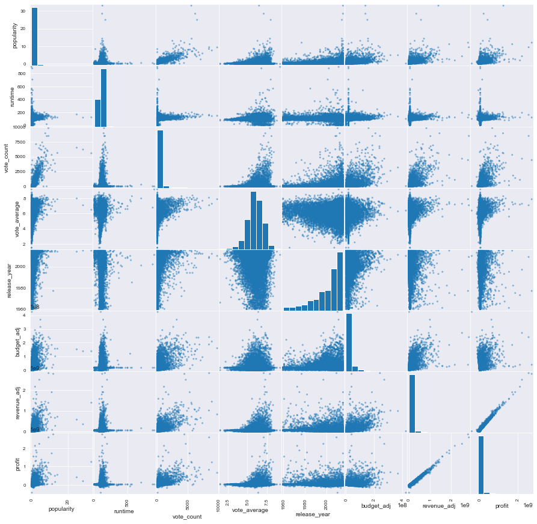

```python
# Using scatter matrix to get general view of the dataset characteristics
pd.plotting.scatter_matrix(df_clean,figsize=(15,15));
```

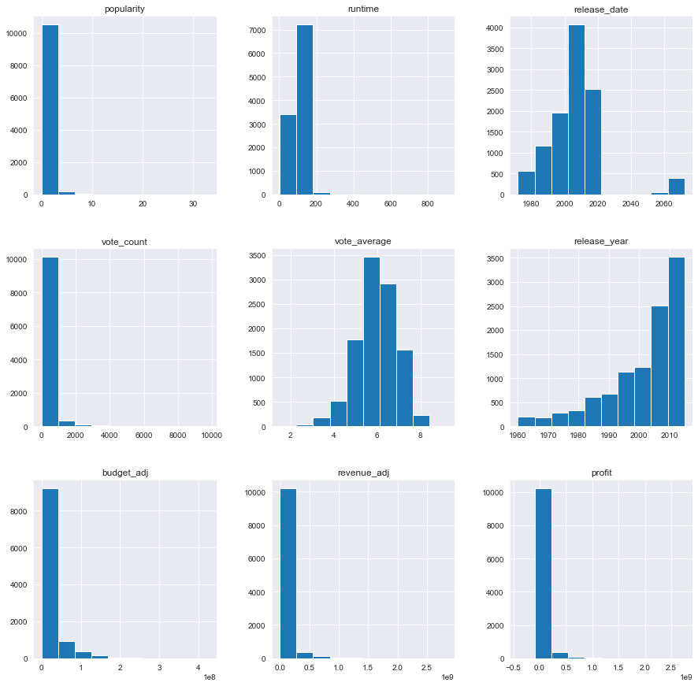

```python
# Using histograms to view the distribution of each column
df_clean.hist(figsize = (15,15));
```

### What are the characteristics associated with higher profit movies?

```python
# View the min, 25%, 50%, 75%, max profit values with Pandas describe
df_clean.profit.describe()
```

```
count    1.073100e+04
mean     5.354181e+07
std      1.213724e+08
min     -4.139124e+08
25%      1.939202e+07
50%      3.424093e+07
75%      3.980942e+07
max      2.750137e+09
Name: profit, dtype: float64
```

```python
# Bin edges that will be used to "cut" the data into groups
bin_edges = [ -4.139124e+08, 0.000000e+00 ,1.939202e+07, 3.980942e+07, 2.750137e+09 ]
```

```python
# Labels for the four profit level groups
bin_names = ['Loss', 'Low_Profit', 'Medium_profit', 'High_Profit']
```

```python
# Creates profit_levels column
df_clean['profit_levels'] = pd.cut(df_clean['profit'], bin_edges, labels=bin_names)

# Checks for successful creation of this column
df_clean.head()
```

|  | popularity | original_title | runtime | release_date | vote_count | vote_average | release_year | budget_adj | revenue_adj | main_genre | hero_actor | main_director | profit | profit_levels |
| --- | --- | --- | --- | --- | --- | --- | --- | --- | --- | --- | --- | --- | --- | --- |
| 0 | 32.985763 | Jurassic World | 124 | 2015-06-09 | 5562 | 6.5 | 2015 | 1.379999e+08 | 1.392446e+09 | Action | Chris Pratt | Colin Trevorrow | 1.254446e+09 | High_Profit |
| 1 | 28.419936 | Mad Max: Fury Road | 120 | 2015-05-13 | 6185 | 7.1 | 2015 | 1.379999e+08 | 3.481613e+08 | Action | Tom Hardy | George Miller | 2.101614e+08 | High_Profit |
| 2 | 13.112507 | Insurgent | 119 | 2015-03-18 | 2480 | 6.3 | 2015 | 1.012000e+08 | 2.716190e+08 | Adventure | Shailene Woodley | Robert Schwentke | 1.704191e+08 | High_Profit |
| 3 | 11.173104 | Star Wars: The Force Awakens | 136 | 2015-12-15 | 5292 | 7.5 | 2015 | 1.839999e+08 | 1.902723e+09 | Action | Harrison Ford | J.J. Abrams | 1.718723e+09 | High_Profit |
| 4 | 9.335014 | Furious 7 | 137 | 2015-04-01 | 2947 | 7.3 | 2015 | 1.747999e+08 | 1.385749e+09 | Action | Vin Diesel | James Wan | 1.210949e+09 | High_Profit |

```python
# Find the mean profit of each profit level with groupby
df_clean.groupby('profit_levels')['profit'].mean()
```

```
profit_levels
Loss            -1.609025e+07
Low_Profit       8.592563e+06
Medium_profit    3.360610e+07
High_Profit      1.546414e+08
Name: profit, dtype: float64
```

```python
# Find the mean profit of each profit level with groupby
df_clean.groupby('profit_levels')['popularity'].mean()
```

```
profit_levels
Loss             0.553670
Low_Profit       0.692342
Medium_profit    0.365153
High_Profit      1.278310
Name: popularity, dtype: float64
```

Obviously, higher profit movies has the highest popularity.

```python
# Find the most main director that has the high profit movies
df_clean.groupby('profit_levels').agg(lambda x:x.value_counts().index[0])['main_director']
```

```
profit_levels
Loss                 Renny Harlin
Low_Profit        Martin Scorsese
Medium_profit         Woody Allen
High_Profit      Steven Spielberg
Name: main_director, dtype: object
```

Steven Spielberg is the director with most movies that made high profit.

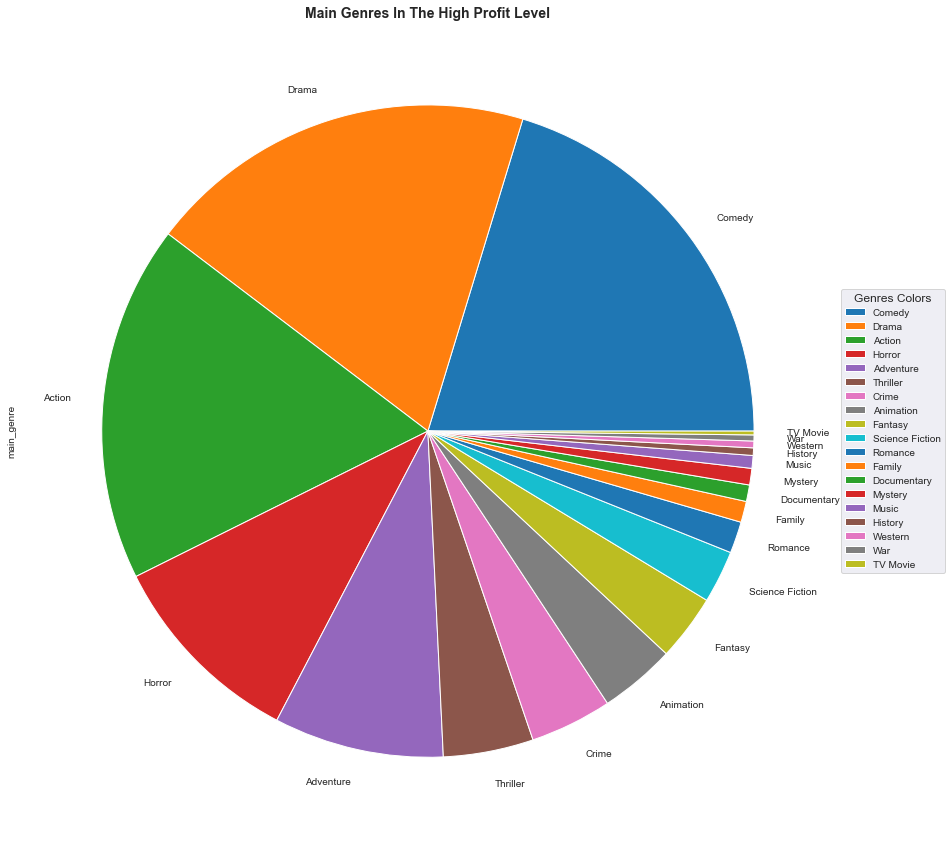

```python
# Find the most genres associated with the higher profit movies with query
df_clean.query('profit_levels == "High_Profit"').main_genre.value_counts().plot.pie(figsize=(15,15));
plt.title('Main Genres In The High Profit Level'.title(), fontsize = 14, weight = "bold")
plt.legend(loc='center left', bbox_to_anchor=(1, 0.5), title="Genres Colors", title_fontsize = 12);
```

Note that the majority of high profit movies are comedy, drama, action, and Horror respectively.

```python
# Find the average runtime of the higher profit movies
HP_runtime_mean=df_clean.query('profit_levels == "High_Profit"')['runtime'].mean()
print('The average runtime of high profit movies is {} minutes'.format(int(HP_runtime_mean)))
```

```
The average runtime of high profit movies is 107 minutes
```

### What are the characteristics associated with most popular movies?

```python
# View the min, 25%, 50%, 75%, max popularity values with Pandas describe
df_clean.popularity.describe()
```

```
count    10731.000000
mean         0.652615
std          1.004804
min          0.000188
25%          0.210765
50%          0.387081
75%          0.720889
max         32.985763
Name: popularity, dtype: float64
```

```python
# Bin edges that will be used to "cut" the data into groups
bin_edges = [ 0.000188, 0.210765 ,0.387081, 0.720889, 32.985763]
```

```python
# Labels for the four popularity level groups
bin_names =['Not Popular','Less Popular','Popular','Very Popular']
```

```python
# Creates popularity_levels column
df_clean['popularity_levels'] = pd.cut(df_clean['popularity'], bin_edges, labels=bin_names)

# Checks for successful creation of this column
df_clean.head()
```

|  | popularity | original_title | runtime | release_date | vote_count | vote_average | release_year | budget_adj | revenue_adj | main_genre | hero_actor | main_director | profit | profit_levels | popularity_levels |
| --- | --- | --- | --- | --- | --- | --- | --- | --- | --- | --- | --- | --- | --- | --- | --- |
| 0 | 32.985763 | Jurassic World | 124 | 2015-06-09 | 5562 | 6.5 | 2015 | 1.379999e+08 | 1.392446e+09 | Action | Chris Pratt | Colin Trevorrow | 1.254446e+09 | High_Profit | Very Popular |
| 1 | 28.419936 | Mad Max: Fury Road | 120 | 2015-05-13 | 6185 | 7.1 | 2015 | 1.379999e+08 | 3.481613e+08 | Action | Tom Hardy | George Miller | 2.101614e+08 | High_Profit | Very Popular |
| 2 | 13.112507 | Insurgent | 119 | 2015-03-18 | 2480 | 6.3 | 2015 | 1.012000e+08 | 2.716190e+08 | Adventure | Shailene Woodley | Robert Schwentke | 1.704191e+08 | High_Profit | Very Popular |
| 3 | 11.173104 | Star Wars: The Force Awakens | 136 | 2015-12-15 | 5292 | 7.5 | 2015 | 1.839999e+08 | 1.902723e+09 | Action | Harrison Ford | J.J. Abrams | 1.718723e+09 | High_Profit | Very Popular |
| 4 | 9.335014 | Furious 7 | 137 | 2015-04-01 | 2947 | 7.3 | 2015 | 1.747999e+08 | 1.385749e+09 | Action | Vin Diesel | James Wan | 1.210949e+09 | High_Profit | Very Popular |

```python
# Find the mean popularity of each popularity level with groupby
df_clean.groupby('popularity_levels')['popularity'].mean()
```

```
popularity_levels
Not Popular     0.121815
Less Popular    0.294168
Popular         0.525795
Very Popular    1.668678
Name: popularity, dtype: float64
```

```python
# Find the most main director that has the higher popularity movies
df_clean.groupby('popularity_levels').agg(lambda x:x.value_counts().index[0])['main_director']
```

```
popularity_levels
Not Popular        Gerald Thomas
Less Popular      Norman Jewison
Popular              Woody Allen
Very Popular    Steven Spielberg
Name: main_director, dtype: object
```

While Steven Spielberg is the director with most movies that made high profit, He also is the director with most popular movies

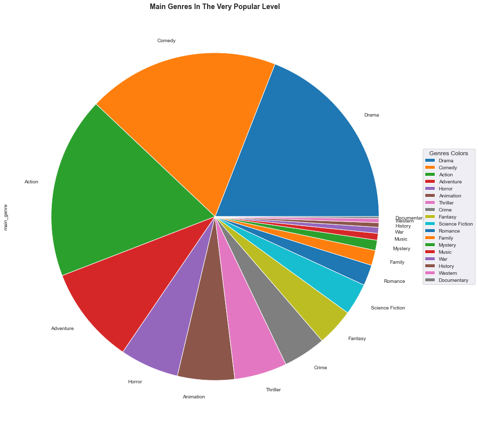

```python
# Find the most genres associated with the higher popularity movies with query
df_clean.query('popularity_levels == "Very Popular"').main_genre.value_counts().plot.pie(figsize=(15,15));
plt.title('Main Genres In The Very Popular Level'.title(), fontsize = 14, weight = "bold")
plt.legend(loc='center left', bbox_to_anchor=(1, 0.5), title="Genres Colors", title_fontsize = 12);
```

Note that the majority of high popularity movies are drama, comedy, action, and adventure respectively. It is very similar to the high profit movies genres.

### Which genres have the highest popularity or the highest profit?

```python
# Find the mean popularity & profit of each main_genre with groupby
model_genres = df_clean.groupby('main_genre')[['popularity','profit']].mean()
model_genres.head()
```

| main_genre | popularity | profit |
| --- | --- | --- |
| Action | 0.837782 | 6.219130e+07 |
| Adventure | 1.219834 | 1.323531e+08 |
| Animation | 0.853208 | 8.195974e+07 |
| Comedy | 0.538260 | 4.458515e+07 |
| Crime | 0.694063 | 4.698971e+07 |

```python
# Find main genre with the highest profit
model_genres.query('profit == '+ str(model_genres.profit.max()))
```

| main_genre | popularity | profit |
| --- | --- | --- |
| Adventure | 1.219834 | 1.323531e+08 |

```python
# Find main genre with the highest popularity
model_genres.query('popularity == '+ str(model_genres.popularity.max()))
```

| main_genre | popularity | profit |
| --- | --- | --- |
| Adventure | 1.219834 | 1.323531e+08 |

```python
# Create a function that save for me repetitive code
def bar_plot(df, col_groupby, col_grouped, orient):
    my_variable = df.groupby([col_groupby])[col_grouped].mean()
    sns.set(rc={'figure.figsize':(20,20) })
    if orient == 'v':
        sns.barplot(y = my_variable, x = my_variable.index, orient = orient, palette="bright");
    elif orient == 'h':
        sns.barplot(x = my_variable, y = my_variable.index, orient = orient, palette="bright");
    plt.title(str(col_groupby+" Vs "+ col_grouped+ " Average").title(), fontsize = 18, weight = "bold")
```

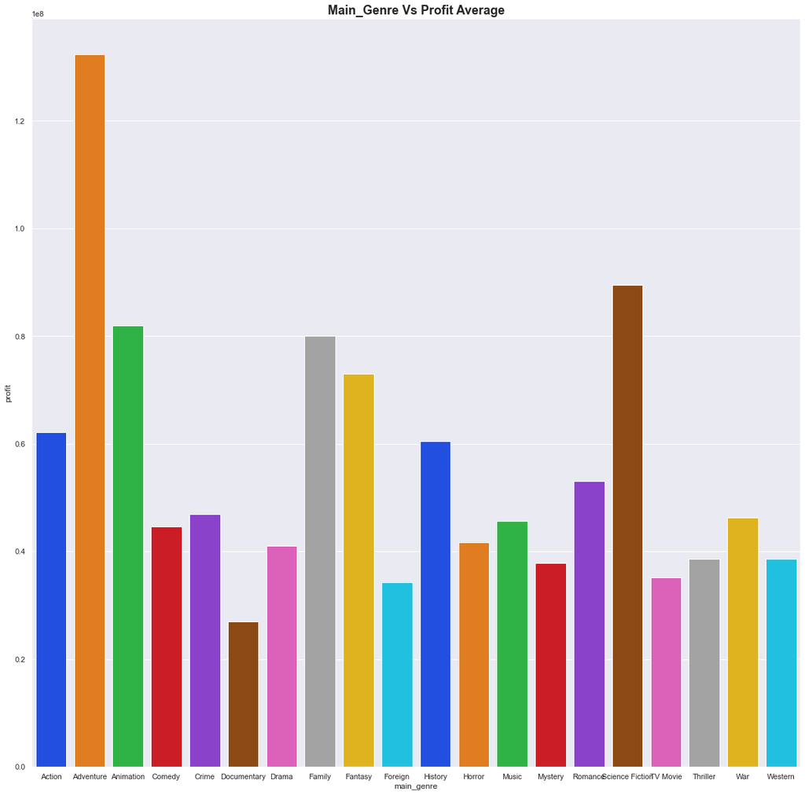

```python
# Plotting the mean profit of each main genre
bar_plot(df_clean,'main_genre', 'profit', 'v')
```

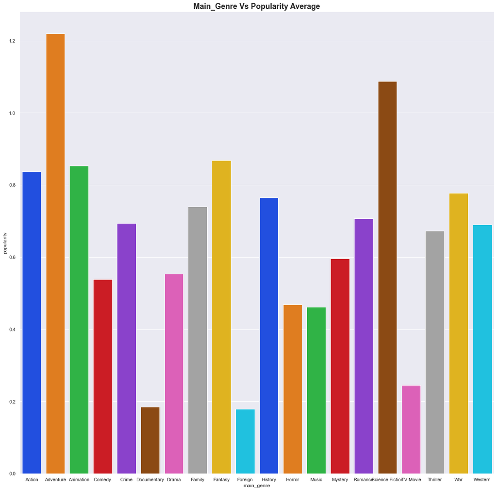

```python
# Plotting the mean popularity of each main genre
bar_plot(df_clean,'main_genre', 'popularity', 'v')
```

It seems that the adventure movies are the most populare movies and have the highest profit. Very interesting!

### Does the vote average affects the movies profit?

```python
# Find the middle value in vote_average column
df_clean.vote_average.median()
```

```
6.0
```

```python
# Splitting the dataset into 2 speratted dataframe
df_high_vote = df_clean.query('vote_average >= 6.0')
df_low_vote = df_clean.query('vote_average < 6.0')
```

```python
# Find the mean proft of the high vote movies
df_high_vote.profit.mean()
```

```
70223223.92870875
```

```python
# Find the mean proft of the low vote movies
df_low_vote.profit.mean()
```

```
34649253.331027426
```

```python
# create common bin intervals for both histograms
bins = np.arange(df_clean.profit.min(), df_clean.profit.max() , 10**8)
```

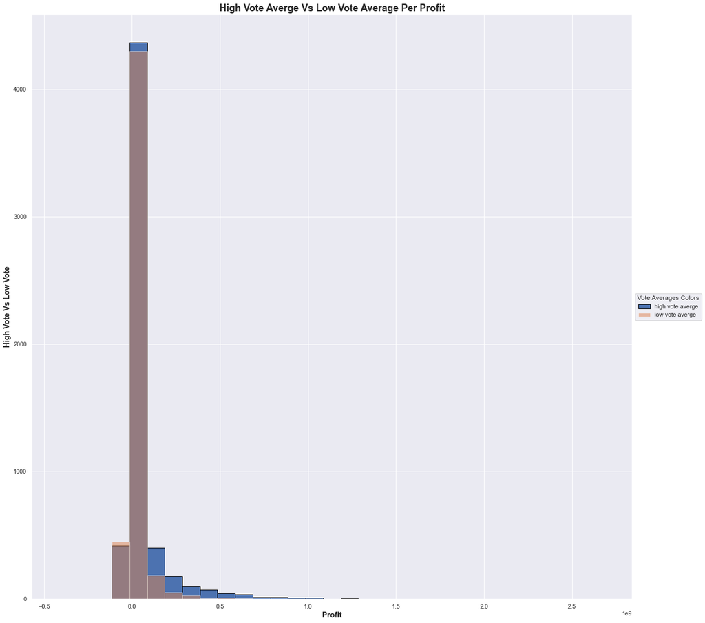

```python
# plotting histogram for high vote average vs low vote average
df_high_vote.profit.hist(alpha=1, bins=bins, label='high vote averge', edgecolor = 'black')
df_low_vote.profit.hist(alpha=0.5, bins=bins, label='low vote averge', edgecolor = 'white')
plt.title('high vote averge vs low vote average per profit'.title(), fontsize = 18, weight = "bold")
plt.xlabel('Profit'.title(), fontsize = 14, weight = "bold")
plt.ylabel('high vote vs low vote'.title(), fontsize = 14, weight = "bold")
plt.legend(loc='center left', bbox_to_anchor=(1, 0.5), title="Vote Averages Colors", title_fontsize = 12);
```

Movies with high vote average have higher profit than movies with low vote average

### Which year have the most popular movies?

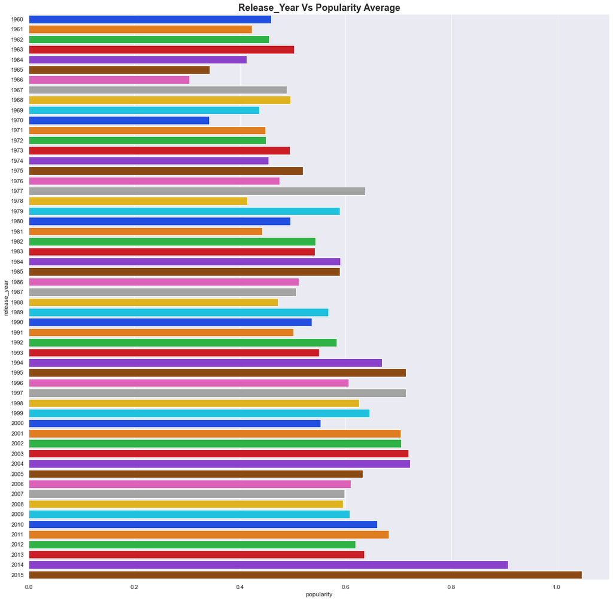

```python
# Plotting the mean popularity of each release year
bar_plot(df_clean,'release_year', 'popularity', 'h')
```

2015 and 2014 are the years with the most popular movies respectively.

### Which year have the highest profit movies?

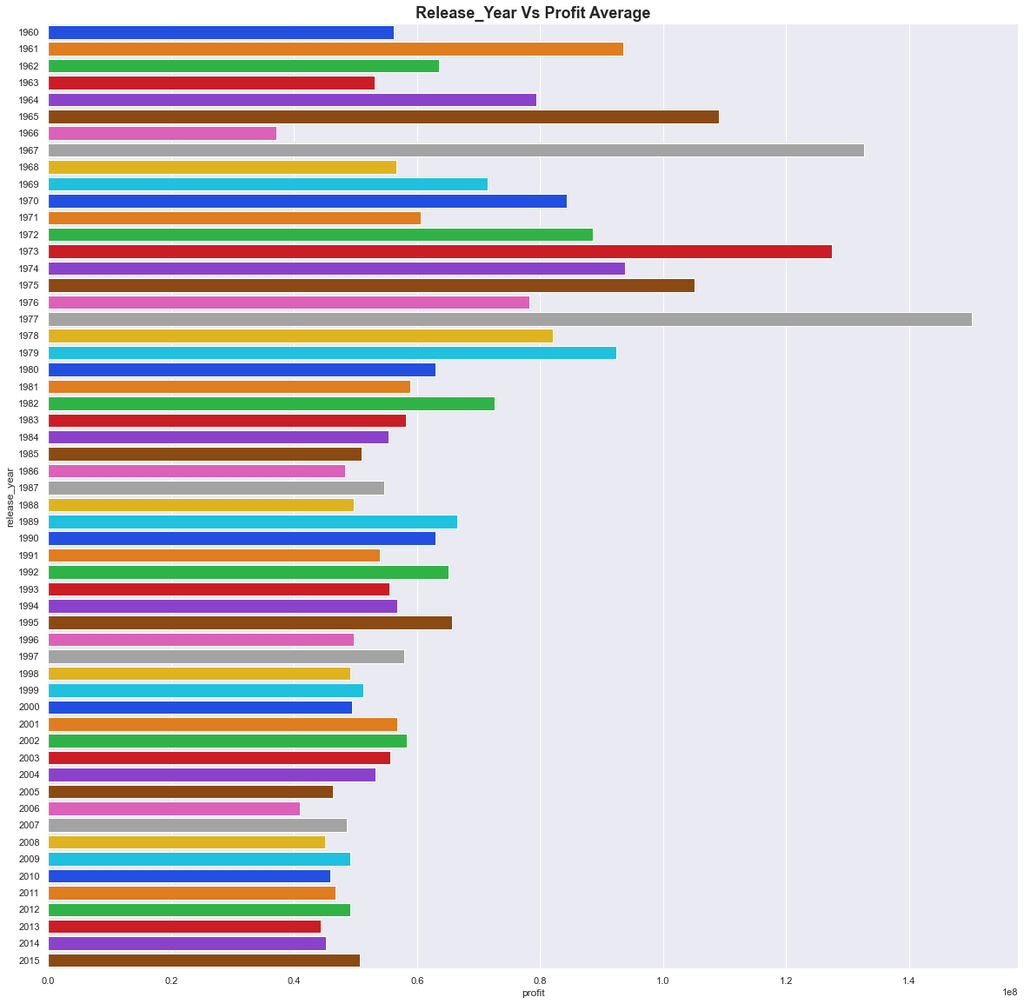

```python
# Plotting the mean profit of each release year
bar_plot(df_clean,'release_year', 'profit', 'h')
```

1977 and 1967 are the years with the most high profit movies respectively.

## Conclusions

### Profit Characterstics

- Higher profit movies has the highest popularity.
- Steven Spielberg is the director with most movies that made high profit.
- Renny Harlin is the director with most movies that were lossing.
- The majority of high profit movies are comedy, drama, action, and Horror respectively.
- The average runtime of a high profit movie is 107 minutes.
- Movies with high vote average have higher profit than movies with low vote average.
- 1977 and 1967 are the years with the most high profit movies respectively.
- 1966 and 2006 is the year with the least low profit movies respectively

### Limitations

- The dataset has many missing values for the budget, revenue and profit.
- The drama, comedy and action genres are most frequent so they appear in the most popular, least popular and different profit levels of the movies.
- The charachteristics of the movie does not guarantee the success or the faliure of it.